# Elite Cues and Public Support for IMF Programs

Results of a Survey Experiment in Tunisia

Robert Kubinec and Sujeong Shim

April 4, 2025

## Introduction

- Our research question:
  - To what extent do the public statements of domestic and international actors affect citizens’ views of IMF negotiations?
  - To what extent is the effectiveness of public statements moderated by ideological distance from the actor?
- Our research builds on the growing literature about how public opinion constrains and shapes the interventions of IOs (Hübscher, Sattler, and Wagner 2023; Dellmuth et al. 2022; Kaya, Handlin, and Gunaydin 2020).

## The IMF and Voters

- IMF interventions are often costly and done only under significant duress.
- Country leaders face a difficult choice between fiscal collapse and voter anger over austerity.
- IMF deals are often quite technical; elite messaging may help guide public opinion (Dellmuth et al. 2022).
- Both domestic and international actors have preferences/messages about IMF interventions.

## Tunisia and the IMF

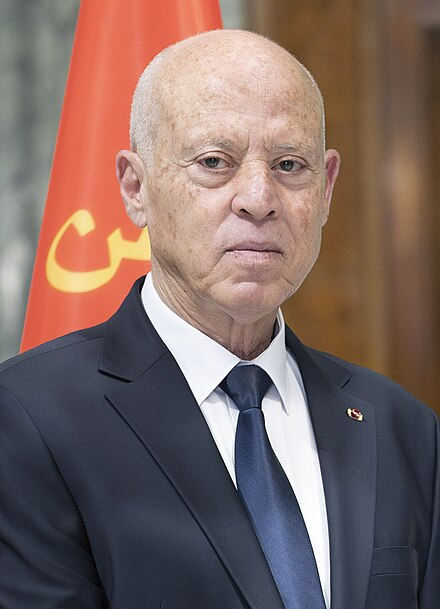

## Research Design

We use endorsements from three actors either opposing or supporting the IMF deal:

1. French President Emmanuel Macron (support)
2. Tunisian President Kais Saied (oppose)
3. Tunisian labor union UGTT (oppose)

Statements were worded similarly about whether the IMF would either facilitate or undermine Tunisia’s economic recovery.

## Partially Crossed Design

To maximize validity & power, we used the following treatment pairings:

1. President Macron
2. President Macron + President Saied
3. President Macron + UGTT

## Outcomes

1. Four outcome measures capturing distinct elements of the IMF deal for Tunisians:
   1. (Approve) How much do you support Tunisia making concessions to the IMF in order to receive more financing to cover the government’s budget needs?
   2. (Concern) How concerned are you about possible negative effects on the Tunisian economy if a deal with the IMF is signed?
   3. (Sovereignty) How concerned are you about the IMF program constraining the government’s policy autonomy?
   4. (Credible) How credible do you think the IMF’s knowledge is about the Tunisian economy?

## Sampling

- Sample drawn from online panels recruited via social media in Tunisia.
- Total of 1,271 respondents, 347 from existing longitudinal panel and 924 from national survey.

## Descriptives: IMF Approval in Tunisia

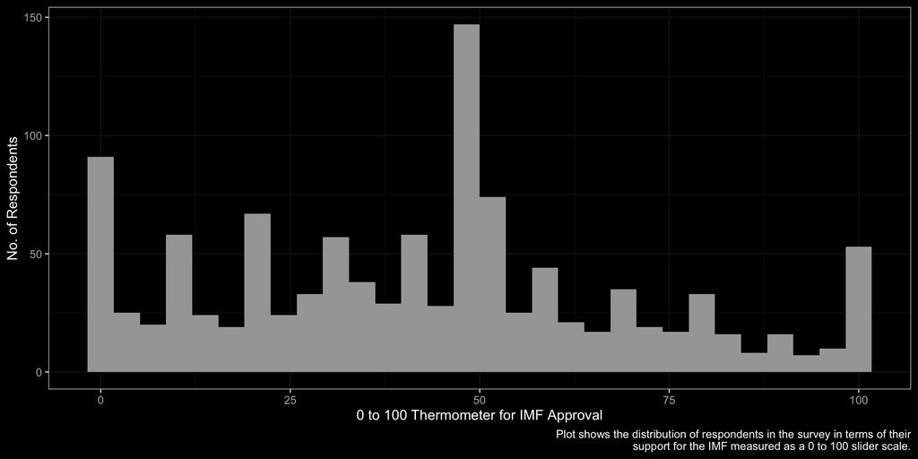

## Ideological Position of Tunisian and Foreign Actors

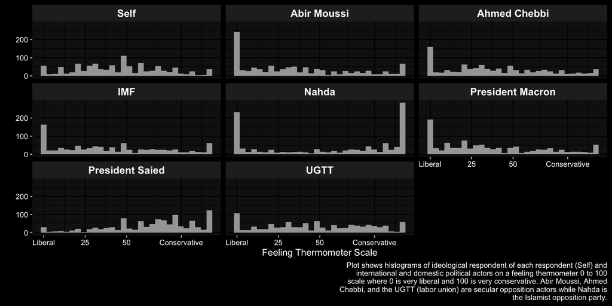

## Main Results

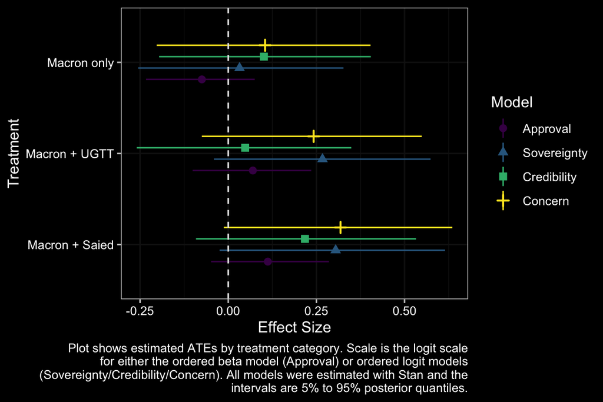

## Ideological Distance Interaction

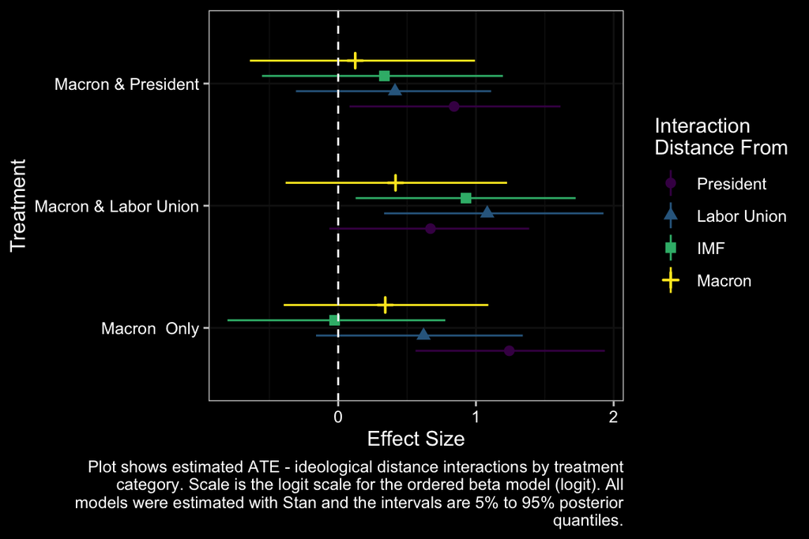

## References

Dellmuth, Lisa, Jan Aart Scholte, Jonas Tallberg, and Soetkin Verhaegen. 2022. “The Elite–Citizen Gap in International Organization Legitimacy.” *American Political Science Review* 116 (1): 283–300. https://doi.org/10.1017/S0003055421000824.

Hübscher, Evelyne, Thomas Sattler, and Markus Wagner. 2023. “Voters and the IMF: Experimental Evidence From European Crisis Countries.” *Comparative Political Studies*, October, 00104140231204229. https://doi.org/10.1177/00104140231204229.

Kaya, Ayse, Sam Handlin, and Hakan Gunaydin. 2020. “Populism and Voter Attitudes Toward International Organizations: Cross-Country and Experimental Evidence on the International Monetary Fund,” January. https://www.peio.me/wp-content/uploads/2020/01/PEIO13_paper_131_1.pdf.